# Checking de Souza et al 2022 soybean yield data

Jim Holland

2022-09-26

# 2020 yield data

Get yield data for 2020 soybean yield trial of transgenic vs WT contol de Souza et al.Science 2022 Aug 19;377(6608):851-854. doi: 10.1126/science.adc9831

```r
dat20 = read.csv("Q:/My Drive/Long soybean data/de Souza 2020 soybean yield data.csv") %>%
  mutate(Entry = as.factor(Entry),
         Block = as.factor(Block))
```

Plot the yield values

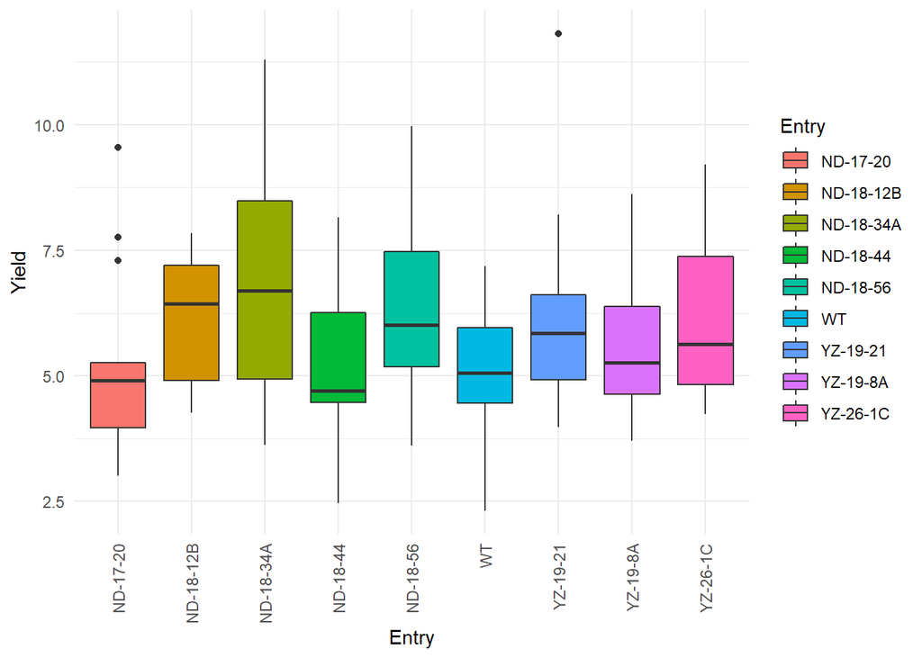

```r
ggplot(dat20, aes(x = Entry, y = Yield)) +
  geom_boxplot(aes(fill = Entry)) +
  theme_minimal() +
  theme(axis.text.x = element_text(angle = 90, vjust = 0.5, hjust=1))
```

linear mixed model for yield, assuming this is an RCBD

```r
rcbd.mod = lmer(Yield ~ (1|Block) + Entry, data = dat20)
summary(rcbd.mod, correlation = F)
```

```
## Linear mixed model fit by REML ['lmerMod']
## Formula: Yield ~ (1 | Block) + Entry
##    Data: dat20
##
## REML criterion at convergence: 512.1
##
## Scaled residuals:
##     Min      1Q  Median      3Q     Max
## -1.6869 -0.6820 -0.1940  0.5258  3.2622
##
## Random effects:
##  Groups   Name        Variance Std.Dev.
##  Block    (Intercept) 0.2645   0.5143
##  Residual             2.6146   1.6170
## Number of obs: 135, groups:  Block, 15
##
## Fixed effects:
##                Estimate Std. Error t value
## (Intercept)     5.11133    0.43811  11.667
## EntryND-18-12B  1.04733    0.59044   1.774
## EntryND-18-34A  1.65000    0.59044   2.795
## EntryND-18-44   0.03333    0.59044   0.056
## EntryND-18-56   1.15733    0.59044   1.960
## EntryWT        -0.02933    0.59044  -0.050
## EntryYZ-19-21   1.15000    0.59044   1.948
## EntryYZ-19-8A   0.68467    0.59044   1.160
## EntryYZ-26-1C   1.07333    0.59044   1.818
```

reduced rcbd model, with no entry effects

```r
rcbd.mod.red = lmer(Yield ~ (1|Block), data = dat20)
```

F-test and p-value for Entry effects using Kenward Roger method

```r
pbkrtest::KRmodcomp(largeModel = rcbd.mod, smallModel = rcbd.mod.red)
```

```
## large : Yield ~ (1 | Block) + Entry
## small : Yield ~ (1 | Block)
##           stat      ndf      ddf F.scaling p.value
## Ftest   2.1633   8.0000 112.0000         1 0.03557 *
## ---
## Signif. codes:  0 '***' 0.001 '**' 0.01 '*' 0.05 '.' 0.1 ' ' 1
```

Fit a fixed lm to the data, this should provide exact same results as Dataset D27

```r
rcbd.lm = lm(Yield ~ Block + Entry, data = dat20)
anova(rcbd.lm)
```

```
## Analysis of Variance Table
##
## Response: Yield
##            Df  Sum Sq Mean Sq F value  Pr(>F)
## Block      14  69.931  4.9950  1.9104 0.03235 *
## Entry       8  45.249  5.6561  2.1633 0.03557 *
## Residuals 112 292.836  2.6146
## ---
## Signif. codes:  0 '***' 0.001 '**' 0.01 '*' 0.05 '.' 0.1 ' ' 1
```

Yes, these results agree with their D27.

Tukey HSD on genotype mean comparisons

```r
tuk = TukeyHSD(aov(rcbd.lm), which = "Entry")
summary(tuk$Entry[,"p adj"])
```

```
##    Min. 1st Qu.  Median    Mean 3rd Qu.    Max.
##  0.1143  0.6332  0.9679  0.7947  0.9996  1.0000
```

Tukey is too conservative here, since we don’t really care about all possible comparisons.  
Really just want to test if each transgenic differs from control. That is 8 tests, so we can correct for multiple testing by using Bonferroni with 8 tests

```r
effects.mat = summary(rcbd.lm)$coefficients

#keep only the entry effects
effects.mat = effects.mat[grepl("Entry", rownames(effects.mat)),]
#fix up the effect names
rownames(effects.mat) = sub("Entry", "", rownames(effects.mat))
effects.mat
```

```
##              Estimate Std. Error     t value    Pr(>|t|)
## ND-18-12B  1.04733333   0.590436  1.77383053 0.078808817
## ND-18-34A  1.65000000   0.590436  2.79454524 0.006115987
## ND-18-44   0.03333333   0.590436  0.05645546 0.955079570
## ND-18-56   1.15733333   0.590436  1.96013355 0.052463954
## WT        -0.02933333   0.590436 -0.04968080 0.960465244
## YZ-19-21   1.15000000   0.590436  1.94771335 0.053952001
## YZ-19-8A   0.68466667   0.590436  1.15959514 0.248679821
## YZ-26-1C   1.07333333   0.590436  1.81786579 0.071757645
```

WT is the control, make all the comparisons against that.  
One of the entries has estimate value of 0.

```r
effects  = effects.mat[,"Estimate"]

wt = effects["WT"]

#remove the intercept and control
others = effects[!names(effects) == "WT"]

#add in the entry with zero coefficient
zero = c(0)
names(zero) = unique(dat20$Entry)[!unique(dat20$Entry) %in% names(effects)]
others = c(others, zero)

#compute the differences between others and wt
difs = others - wt
difs
```

```
##  ND-18-12B  ND-18-34A   ND-18-44   ND-18-56   YZ-19-21   YZ-19-8A   YZ-26-1C
## 1.07666667 1.67933333 0.06266667 1.18666667 1.17933333 0.71400000 1.10266667
##   ND-17-20
## 0.02933333
```

Compute the p-values for these comparisons. Std errors of coefficients are all the same, makes this easy

```r
# compute standard error of mean difference:
sed = sigma(rcbd.lm)*sqrt(2/15)
tvalues = difs/sed
pvalues = dt(tvalues, df = df.residual(rcbd.mod))
pvalues
```

```
##   ND-18-12B   ND-18-34A    ND-18-44    ND-18-56    YZ-19-21    YZ-19-8A
## 0.076162857 0.007666485 0.395884705 0.053693624 0.055014315 0.191338142
##    YZ-26-1C    ND-17-20
## 0.070325928 0.397643791
```

The alpha 0.05 level should be divided by 8 to get Bonferroni adjusted threshold p-value for significance

```r
0.05/8
```

```
## [1] 0.00625
```

Do any of the 8 comparisons pass the Bonferroni adjustment?

```r
pvalues < (0.05/8)
```

```
## ND-18-12B ND-18-34A  ND-18-44  ND-18-56  YZ-19-21  YZ-19-8A  YZ-26-1C  ND-17-20
##     FALSE     FALSE     FALSE     FALSE     FALSE     FALSE     FALSE     FALSE
```

They also claim to have used Benjamini-Hochberg FDR. Let’s get the BH FDR adjusted p-values

```r
p.adjust(pvalues, method = "BH")
```

```
##  ND-18-12B  ND-18-34A   ND-18-44   ND-18-56   YZ-19-21   YZ-19-8A   YZ-26-1C
## 0.12186057 0.06133188 0.39764379 0.12186057 0.12186057 0.25511752 0.12186057
##   ND-17-20
## 0.39764379
```

Are any of these less than 0.05?

```r
p.adjust(pvalues, method = "BH") < 0.05
```

```
## ND-18-12B ND-18-34A  ND-18-44  ND-18-56  YZ-19-21  YZ-19-8A  YZ-26-1C  ND-17-20
##     FALSE     FALSE     FALSE     FALSE     FALSE     FALSE     FALSE     FALSE
```

No.

# 2021 data

```r
dat21 = read.csv("Q:/My Drive/Long soybean data/de Souza 2021 yield data.csv") %>%
  mutate(Entry = as.factor(Entry),
         Block = as.factor(Block))
```

Plot the yield values

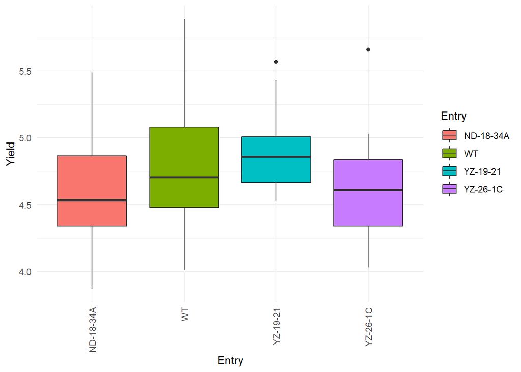

```r
ggplot(dat21, aes(x = Entry, y = Yield)) +
  geom_boxplot(aes(fill = Entry)) +
  theme_minimal() +
  theme(axis.text.x = element_text(angle = 90, vjust = 0.5, hjust=1))
```

The yield rankings have changed dramatically across years. Fit these data to fixed effects ANOVA model

```r
rcbd.lm21 = lm(Yield ~ Block + Entry, data = dat21)
anova(rcbd.lm21)
```

```
## Analysis of Variance Table
##
## Response: Yield
##           Df Sum Sq Mean Sq F value Pr(>F)
## Block     15 1.7819 0.11879  0.5593 0.8899
## Entry      3 0.8005 0.26682  1.2561 0.3008
## Residuals 45 9.5585 0.21241
```

No significant differences.  
Compute the means to see if they agree with Fig S12. Data are balanced, so simple means are fine:

```r
dat21 %>% group_by(Entry) %>%
  summarize(Mean_yield = mean(Yield))
```

```
## # A tibble: 4 x 2
##   Entry     Mean_yield
## * <fct>          <dbl>
## 1 ND-18-34A       4.64
## 2 WT              4.82
## 3 YZ-19-21        4.89
## 4 YZ-26-1C        4.64
```

Looks like their figure.

#Response of soybean yield to planting density Data from Parks et al. 1982 TN Agric. Exp. Stn. Bull 615. Cited in Duncan 1986 Crop Science 26:584-588.

Get the data

```r
parks = read.csv("Q:/My Drive/Long soybean data/Parks 1983 soybean yield density data.csv")
parks.long = parks %>%
  pivot_longer(cols = c("Yield_g_m2", "Yield_g_plant"), values_to = "Yield", names_to = "Yield_type") %>%
  mutate(Yield_type = ifelse(Yield_type == "Yield_g_m2", "Yield (g/m^2)", "Yield (g/plant)"),
         Row.width = as.factor(Row.width))
```

Plot the yields per area and yield per plant as a function of population density

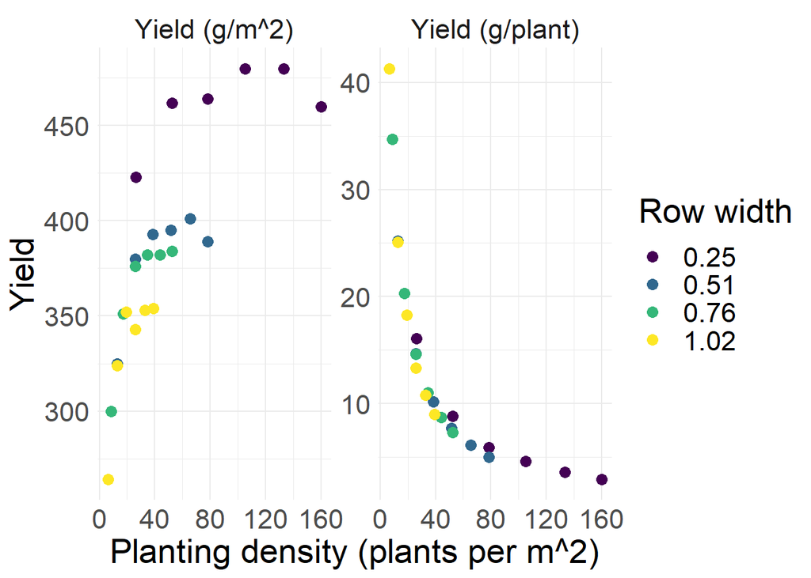

```r
density.response.plot = ggplot(parks.long, aes(x = Population, y = Yield)) +
  geom_point(aes(colour = Row.width), size = 3) +
  facet_wrap(facets = ~Yield_type, scales = "free") +
  scale_color_viridis(discrete = T, name = "Row width") +
  xlab("Planting density (plants per m^2)") +
  theme_minimal() +
  theme(text=element_text(size=21))

density.response.plot
```

Save the graph

```r
ggsave("Q:/My Drive/Long soybean data/Parks 1983 soybean yield density graph.png", density.response.plot, width = 10, height = 8, units = "in")
```

Get the data from Schutz and Bernard on G x E Interactions in the Regional Tesing of Soybean Strains. Crop Science 1967

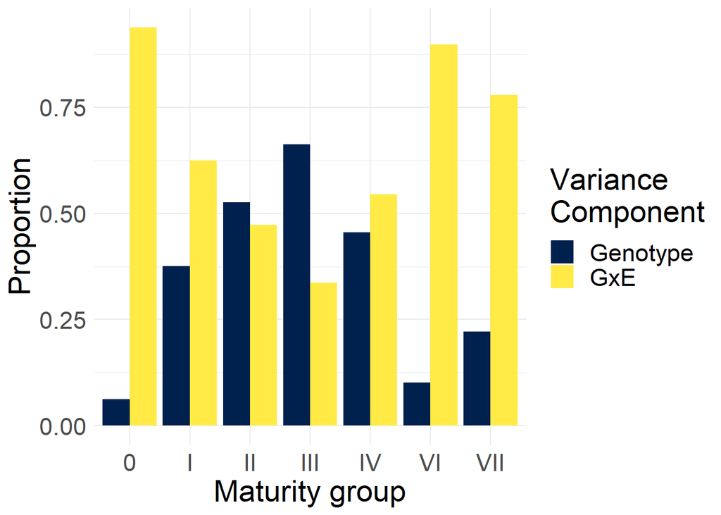

```r
gxe = read.csv("Q:/My Drive/Long soybean data/Vg and Vge estimates soybean yield Shutz Bernard 1967.csv") %>%
  mutate(Vsum = Vg+ Vge,
         Genotype = Vg/Vsum,
         GxE = Vge/Vsum) %>%
  pivot_longer(cols = c('Genotype', 'GxE'), names_to = "Component", values_to = "Proportion")

gxe.plot = ggplot(gxe, aes(x = Maturity_group, y = Proportion)) +
  geom_bar(stat = "identity", aes(fill = Component), position = "dodge") +
  scale_fill_viridis(discrete = T, option = "cividis", name = "Variance\nComponent") +
  xlab("Maturity group") +
  theme_minimal()+
  theme(text=element_text(size=21))

gxe.plot
```

Write the figure to a file

```r
ggsave("Q:/My Drive/Long soybean data/Vg and Vge estimates soybean yield.png",gxe.plot, width = 10, height = 8, units = "in")
```